# Introduction to Data Visualization with Seaborn

Instructor: DataCamp Content Creator

# 1 Introduction to Seaborn

## 1.1 Making a scatter plot with lists

In this exercise, we’ll use a dataset that contains information about 227 countries. This dataset has lots of interesting information on each country, such as the country’s birth rates, death rates, and its gross domestic product (GDP). GDP is the value of all the goods and services produced in a year, expressed as dollars per person.

We’ve created three lists of data from this dataset to get you started. `gdp` is a list that contains the value of GDP per country, expressed as dollars per person. `phones` is a list of the number of mobile phones per 1,000 people in that country. Finally, `percent_literate` is a list that contains the percent of each country’s population that can read and write.

**Instructions**

- Import Matplotlib and Seaborn using the standard naming convention.
- Create a scatter plot of GDP (`gdp`) vs. number of phones per 1000 people (`phones`).
- Display the plot.
- Change the scatter plot so it displays the percent of the population that can read and write (`percent_literate`) on the y-axis.

**Answer**

```python
# added/edited
import pandas as pd
countries = pd.read_csv("countries-of-the-world.csv")
gdp = list(map(float,[word.replace(",",".") for word in countries["GDP ($ per capita)"].astype(str)]))
phones = list(map(float,[word.replace(",",".") for word in countries["Phones (per 1000)"].astype(str)]))
percent_literate = list(map(float,[word.replace(",",".") for word in countries["Literacy (%)"].astype(str)]))
```

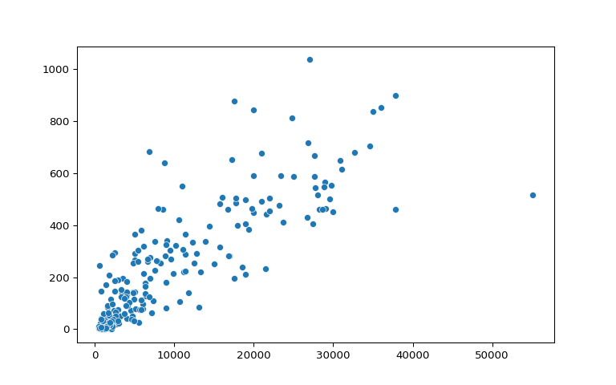

```python
# Import Matplotlib and Seaborn
import matplotlib.pyplot as plt
import seaborn as sns

# Create scatter plot with GDP on the x-axis and number of phones on the y-axis
sns.scatterplot(x=gdp, y=phones)

# Show plot
plt.show()
```

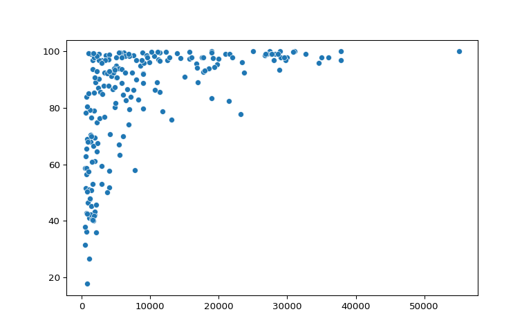

```python
# Change this scatter plot to have percent literate on the y-axis
sns.scatterplot(x=gdp, y=percent_literate)

# Show plot
plt.show()
```

## 1.2 Making a count plot with a list

In the last exercise, we explored a dataset that contains information about 227 countries. Let’s do more exploration of this data - specifically, how many countries are in each region of the world?

To do this, we’ll need to use a count plot. Count plots take in a categorical list and return bars that represent the number of list entries per category. You can create one here using a list of regions for each country, which is a variable named `region`.

**Instructions**

- Import Matplotlib and Seaborn using the standard naming conventions.
- Use Seaborn to create a count plot with `region` on the y-axis.
- Display the plot.

**Answer**

```python
# added/edited
region = countries["Region"]
```

[figure not shown]

```python
# Import Matplotlib and Seaborn
import matplotlib.pyplot as plt
import seaborn as sns

# Create count plot with region on the y-axis
sns.countplot(y=region)

# Show plot
plt.show()
```

## 1.3 “Tidy” vs. “untidy” data

Here, we have a sample dataset from a survey of children about their favorite animals. But can we use this dataset as-is with Seaborn? Let’s use pandas to import the csv file with the data collected from the survey and determine whether it is tidy, which is essential to having it work well with Seaborn.

To get you started, the filepath to the csv file has been assigned to the variable `csv_filepath`.

Note that because `csv_filepath` is a Python variable, you will not need to put quotation marks around it when you read the csv.

**Instructions**

- Read the csv file located at `csv_filepath` into a DataFrame named `df`.
- Print the head of `df` to show the first five rows.

**Answer**

```python
# added/edited
csv_filepath = "1.2.1_example_csv.csv"
```

```python
# Import pandas
import pandas as pd

# Create a DataFrame from csv file
df = pd.read_csv(csv_filepath)

# Print the head of df
print(df.head())
```

```
##   Unnamed: 0               How old are you?
## 0     Marion                             12
## 1      Elroy                             16
## 2        NaN  What is your favorite animal?
## 3     Marion                            dog
## 4      Elroy                            cat
```

## 1.4 Making a count plot with a DataFrame

In this exercise, we’ll look at the responses to a survey sent out to young people. Our primary question here is: how many young people surveyed report being scared of spiders? Survey participants were asked to agree or disagree with the statement “I am afraid of spiders”. Responses vary from 1 to 5, where 1 is “Strongly disagree” and 5 is “Strongly agree”.

To get you started, the filepath to the csv file with the survey data has been assigned to the variable `csv_filepath`.

Note that because `csv_filepath` is a Python variable, you will not need to put quotation marks around it when you read the csv.

**Instructions**

- Import Matplotlib, pandas, and Seaborn using the standard names.
- Create a DataFrame named `df` from the csv file located at `csv_filepath`.
- Use the `countplot()` function with the `x=` and `data=` arguments to create a count plot with the `"Spiders"` column values on the x-axis.
- Display the plot.

**Answer**

```python
# added/edited
csv_filepath = "young-people-survey-responses.csv"
```

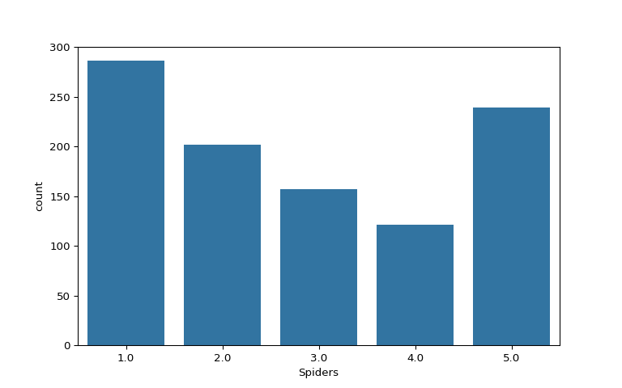

```python
# Import Matplotlib, pandas, and Seaborn
import matplotlib.pyplot as plt
import pandas as pd
import seaborn as sns

# Create a DataFrame from csv file
df = pd.read_csv(csv_filepath)

# Create a count plot with "Spiders" on the x-axis
sns.countplot(x="Spiders", data=df)

# Display the plot
plt.show()
```

## 1.5 Hue and scatter plots

In the prior video, we learned how `hue` allows us to easily make subgroups within Seaborn plots. Let’s try it out by exploring data from students in secondary school. We have a lot of information about each student like their age, where they live, their study habits and their extracurricular activities.

For now, we’ll look at the relationship between the number of absences they have in school and their final grade in the course, segmented by where the student lives (rural vs. urban area).

**Instructions**

- Create a scatter plot with `"absences"` on the x-axis and final grade (`"G3"`) on the y-axis using the DataFrame `student_data`. Color the plot points based on `"location"` (urban vs. rural).
- Make `"Rural"` appear before `"Urban"` in the plot legend.

**Answer**

```python
# added/edited
student_data = pd.read_csv("student-alcohol-consumption.csv")
```

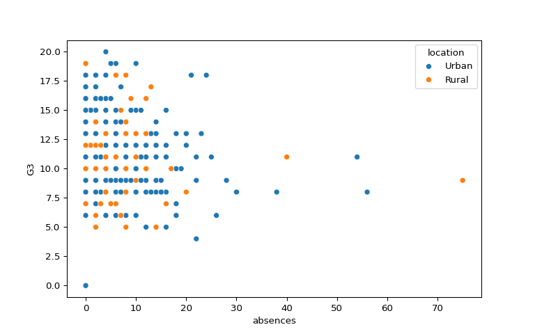

```python
# Import Matplotlib and Seaborn
import matplotlib.pyplot as plt
import seaborn as sns

# Create a scatter plot of absences vs. final grade
sns.scatterplot(x="absences", y="G3",
                data=student_data,
                hue="location")

# Show plot
plt.show()
```

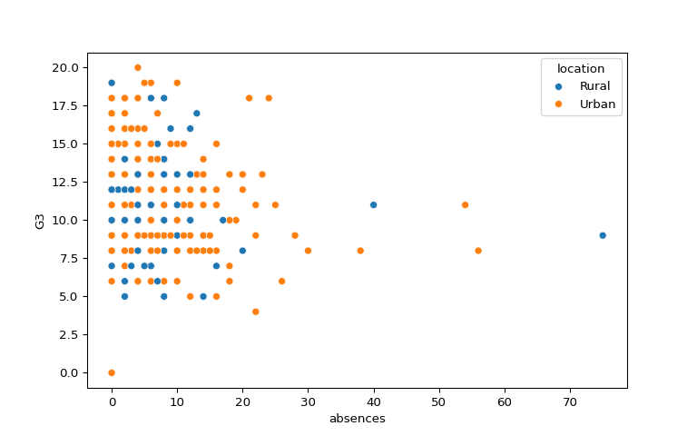

```python
# Change the legend order in the scatter plot
sns.scatterplot(x="absences", y="G3",
                data=student_data,
                hue="location",
                hue_order=["Rural", "Urban"])

# Show plot
plt.show()
```

## 1.6 Hue and count plots

Let’s continue exploring our dataset from students in secondary school by looking at a new variable. The `"school"` column indicates the initials of which school the student attended - either “GP” or “MS”.

In the last exercise, we created a scatter plot where the plot points were colored based on whether the student lived in an urban or rural area. How many students live in urban vs. rural areas, and does this vary based on what school the student attends? Let’s make a count plot with subgroups to find out.

**Instructions**

- Fill in the `palette_colors` dictionary to map the `"Rural"` location value to the color `"green"` and the `"Urban"` location value to the color `"blue"`.
- Create a count plot with `"school"` on the x-axis using the `student_data` DataFrame.
  - Add subgroups to the plot using `"location"` variable and use the `palette_colors` dictionary to make the location subgroups green and blue.

**Answer**

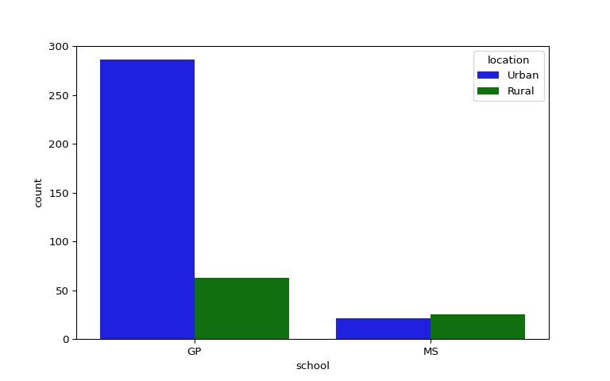

```python
# Import Matplotlib and Seaborn
import matplotlib.pyplot as plt
import seaborn as sns

# Create a dictionary mapping subgroup values to colors
palette_colors = {"Rural": "green", "Urban": "blue"}

# Create a count plot of school with location subgroups
sns.countplot(x="school", data=student_data,
              hue="location",
              palette=palette_colors)

# Display plot
plt.show()
```

# 2 Visualizing Two Quantitative Variables

## 2.1 Creating subplots with col and row

We’ve seen in prior exercises that students with more absences (`"absences"`) tend to have lower final grades (`"G3"`). Does this relationship hold regardless of how much time students study each week?

To answer this, we’ll look at the relationship between the number of absences that a student has in school and their final grade in the course, creating separate subplots based on each student’s weekly study time (`"study_time"`).

Seaborn has been imported as `sns` and `matplotlib.pyplot` has been imported as `plt`.

**Instructions**

Modify the code to use `relplot()` instead of `scatterplot()`.

Modify the code to create one scatter plot for each level of the variable `"study_time"`, arranged in columns.

Adapt your code to create one scatter plot for each level of a student’s weekly study time, this time arranged in rows.

**Answer**

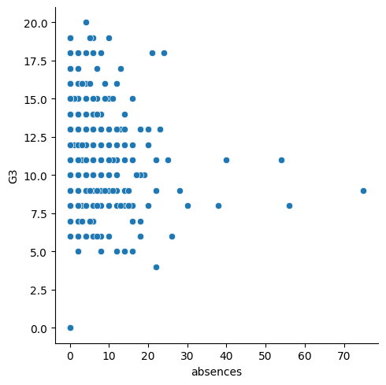

```python
# Change to use relplot() instead of scatterplot()
sns.relplot(x="absences", y="G3",
            data=student_data,
            kind="scatter")
```

```python
plt.close()  # added/edited
```

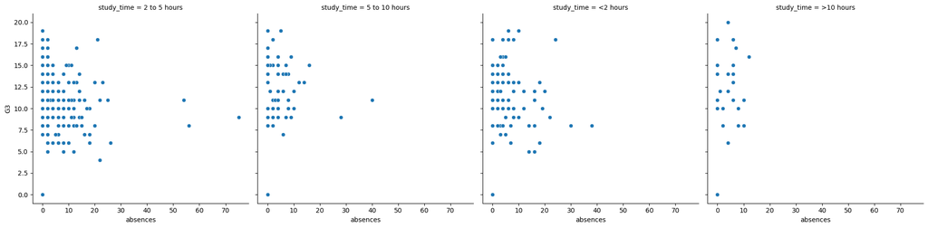

```python
# Change to make subplots based on study time
sns.relplot(x="absences", y="G3",
            data=student_data,
            kind="scatter",
            col="study_time")
```

```python
plt.close()  # added/edited
```

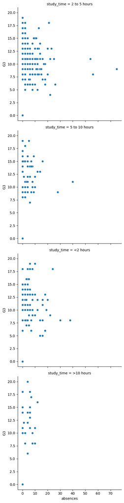

```python
# Change this scatter plot to arrange the plots in rows instead of columns
sns.relplot(x="absences", y="G3",
            data=student_data,
            kind="scatter",
            row="study_time")
```

```python
plt.close()  # added/edited
```

## 2.2 Creating two-factor subplots

Let’s continue looking at the `student_data` dataset of students in secondary school. Here, we want to answer the following question: does a student’s first semester grade (`"G1"`) tend to correlate with their final grade (`"G3"`)?

There are many aspects of a student’s life that could result in a higher or lower final grade in the class. For example, some students receive extra educational support from their school (`"schoolsup"`) or from their family (`"famsup"`), which could result in higher grades. Let’s try to control for these two factors by creating subplots based on whether the student received extra educational support from their school or family.

Seaborn has been imported as `sns` and `matplotlib.pyplot` has been imported as `plt`.

**Instructions**

- Use `relplot()` to create a scatter plot with `"G1"` on the x-axis and `"G3"` on the y-axis, using the `student_data` DataFrame.
- Create **column** subplots based on whether the student received support from the school (`"schoolsup"`), ordered so that “yes” comes before “no”.
- Add **row** subplots based on whether the student received support from the family (`"famsup"`), ordered so that “yes” comes before “no”. This will result in subplots based on two factors.

**Answer**

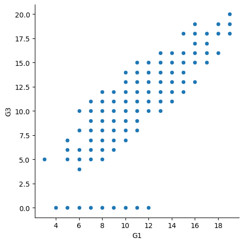

```python
# Create a scatter plot of G1 vs. G3
sns.relplot(x="G1", y="G3",
            data=student_data,
            kind="scatter")
```

```python
plt.close()  # added/edited
```

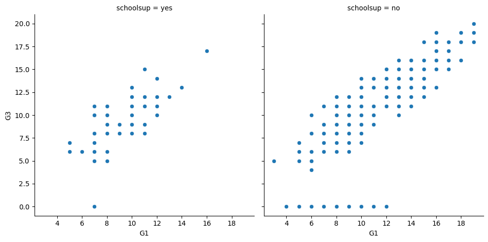

```python
# Adjust to add subplots based on school support
sns.relplot(x="G1", y="G3",
            data=student_data,
            kind="scatter",
            col="schoolsup",
            col_order=["yes", "no"])
```

```python
plt.close()  # added/edited
```

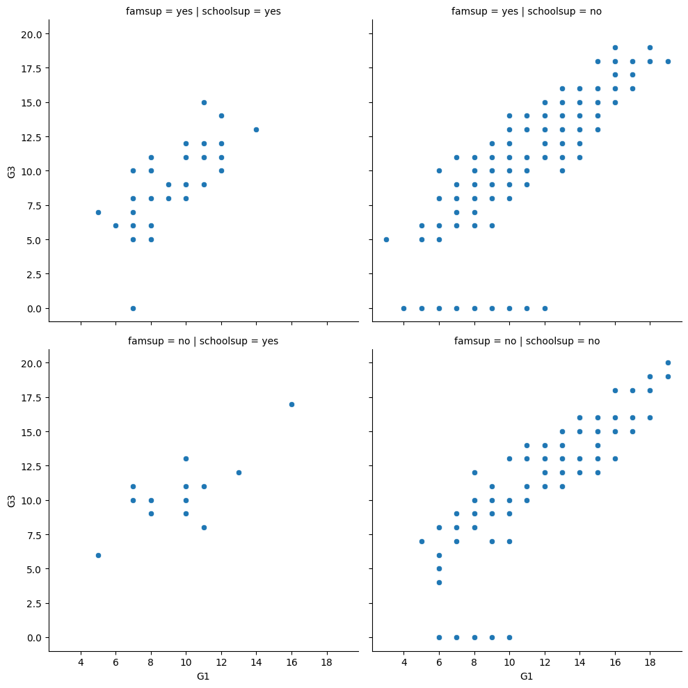

```python
# Adjust further to add subplots based on family support
sns.relplot(x="G1", y="G3",
            data=student_data,
            kind="scatter",
            col="schoolsup",
            col_order=["yes", "no"],
            row="famsup",
            row_order=["yes", "no"])
```

```python
plt.close()  # added/edited
```

## 2.3 Changing the size of scatter plot points

In this exercise, we’ll explore Seaborn’s `mpg` dataset, which contains one row per car model and includes information such as the year the car was made, the number of miles per gallon (“M.P.G.”) it achieves, the power of its engine (measured in “horsepower”), and its country of origin.

What is the relationship between the power of a car’s engine (`"horsepower"`) and its fuel efficiency (`"mpg"`)? And how does this relationship vary by the number of cylinders (`"cylinders"`) the car has? Let’s find out.

Let’s continue to use `relplot()` instead of `scatterplot()` since it offers more flexibility.

**Instructions**

- Use `relplot()` and the `mpg` DataFrame to create a scatter plot with `"horsepower"` on the x-axis and `"mpg"` on the y-axis. Vary the size of the points by the number of cylinders in the car (`"cylinders"`).
- To make this plot easier to read, use `hue` to vary the color of the points by the number of cylinders in the car (`"cylinders"`).

**Answer**

```python
# added/edited
mpg = pd.read_csv("mpg.csv")
```

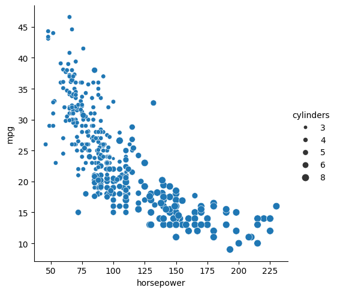

```python
# Import Matplotlib and Seaborn
import matplotlib.pyplot as plt
import seaborn as sns

# Create scatter plot of horsepower vs. mpg
sns.relplot(x="horsepower", y="mpg",
            data=mpg, kind="scatter",
            size="cylinders")
```

```python
plt.close()  # added/edited
```

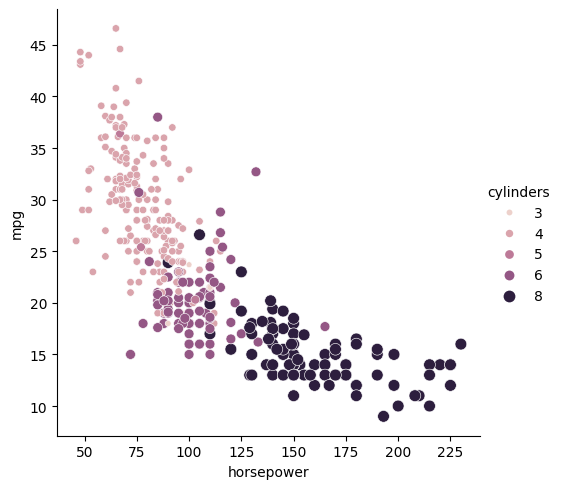

```python
# Create scatter plot of horsepower vs. mpg
sns.relplot(x="horsepower", y="mpg",
            data=mpg, kind="scatter",
            size="cylinders", hue="cylinders")
```

```python
plt.close()  # added/edited
```

## 2.4 Changing the style of scatter plot points

Let’s continue exploring Seaborn’s `mpg` dataset by looking at the relationship between how fast a car can accelerate (`"acceleration"`) and its fuel efficiency (`"mpg"`). Do these properties vary by country of origin (`"origin"`)?

Note that the `"acceleration"` variable is the time to accelerate from 0 to 60 miles per hour, in seconds. Higher values indicate slower acceleration.

**Instructions**

- Use `relplot()` and the `mpg` DataFrame to create a scatter plot with `"acceleration"` on the x-axis and `"mpg"` on the y-axis. Vary the style and color of the plot points by country of origin (`"origin"`).

**Answer**

```python
# added/edited
mpg = pd.read_csv("mpg.csv")
```

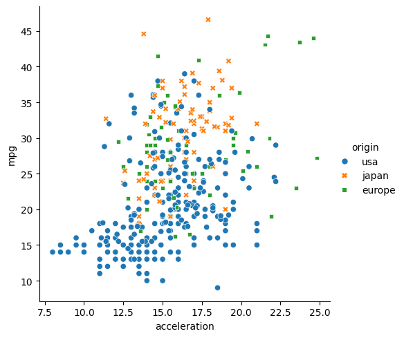

```python
# Import Matplotlib and Seaborn
import matplotlib.pyplot as plt
import seaborn as sns

# Create a scatter plot of acceleration vs. mpg
sns.relplot(x="acceleration", y="mpg",
            data=mpg, kind="scatter",
            style="origin", hue="origin")
```

```python
plt.close()  # added/edited
```

## 2.5 Interpreting line plots

In this exercise, we’ll continue to explore Seaborn’s `mpg` dataset, which contains one row per car model and includes information such as the year the car was made, its fuel efficiency (measured in “miles per gallon” or “M.P.G”), and its country of origin (USA, Europe, or Japan).

How has the average miles per gallon achieved by these cars changed over time? Let’s use line plots to find out!

**Instructions**

- Use `relplot()` and the `mpg` DataFrame to create a line plot with `"model_year"` on the x-axis and `"mpg"` on the y-axis.

**Answer**

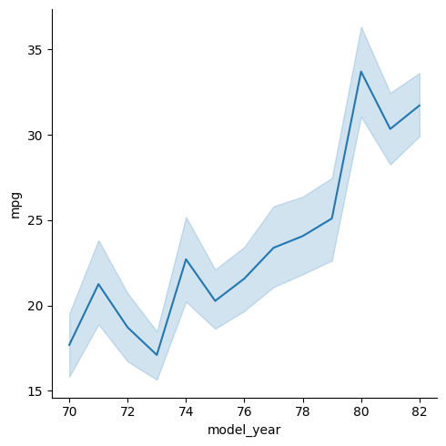

```python
# Import Matplotlib and Seaborn
import matplotlib.pyplot as plt
import seaborn as sns

# Create line plot
sns.relplot(x="model_year", y="mpg",
            data=mpg, kind="line")
```

```python
plt.close()  # added/edited
```

## 2.6 Visualizing standard deviation with line plots

In the last exercise, we looked at how the average miles per gallon achieved by cars has changed over time. Now let’s use a line plot to visualize how the *distribution* of miles per gallon has changed over time.

Seaborn has been imported as `sns` and `matplotlib.pyplot` has been imported as `plt`.

**Instructions**

- Change the plot so the shaded area shows the standard deviation instead of the confidence interval for the mean.

**Answer**

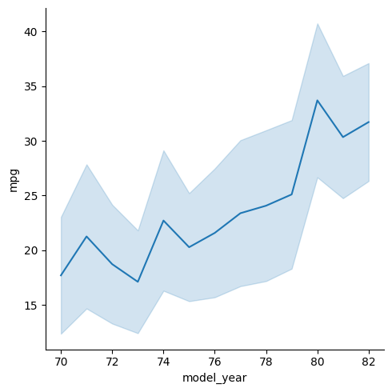

```python
# Make the shaded area show the standard deviation
sns.relplot(x="model_year", y="mpg",
            data=mpg, kind="line",
            ci="sd")
```

```python
plt.close()  # added/edited
```

## 2.7 Plotting subgroups in line plots

Let’s continue to look at the `mpg` dataset. We’ve seen that the average miles per gallon for cars has increased over time, but how has the average horsepower for cars changed over time? And does this trend differ by country of origin?

**Instructions**

- Use `relplot()` and the `mpg` DataFrame to create a line plot with `"model_year"` on the x-axis and `"horsepower"` on the y-axis. Turn off the confidence intervals on the plot.
- Create different lines for each country of origin (`"origin"`) that vary in both line style and color.
- Add markers for each data point to the lines.
- Use the `dashes` parameter to use solid lines for all countries, while still allowing for different marker styles for each line.

**Answer**

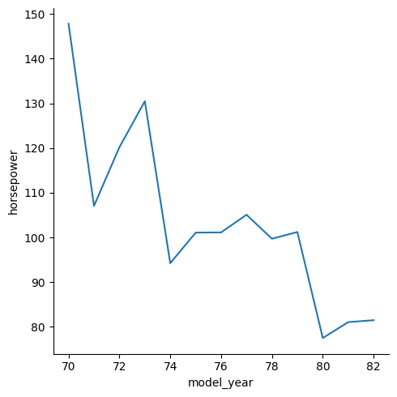

```python
# Import Matplotlib and Seaborn
import matplotlib.pyplot as plt
import seaborn as sns

# Create line plot of model year vs. horsepower
sns.relplot(x="model_year", y="horsepower",
            data=mpg, kind="line",
            ci=None)
```

```python
plt.close()  # added/edited
```

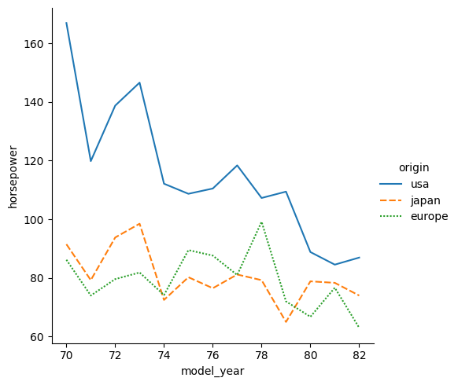

```python
# Change to create subgroups for country of origin
sns.relplot(x="model_year", y="horsepower",
            data=mpg, kind="line",
            ci=None, style="origin",
            hue="origin")
```

```python
plt.close()  # added/edited
```

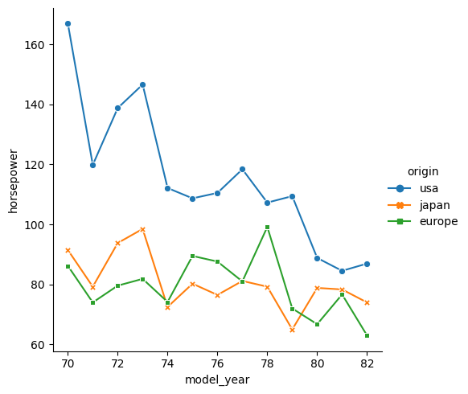

```python
# Add markers and make each line have the same style
sns.relplot(x="model_year", y="horsepower",
            data=mpg, kind="line",
            ci=None, style="origin",
            hue="origin", markers=True,
            dashes=False)
```

```python
plt.close()  # added/edited
```

# 3 Visualizing a Categorical and a Quantitative Variable

## 3.1 Count plots

In this exercise, we’ll return to exploring our dataset that contains the responses to a survey sent out to young people. We might suspect that young people spend a lot of time on the internet, but how much do they report using the internet each day? Let’s use a count plot to break down the number of survey responses in each category and then explore whether it changes based on age.

As a reminder, to create a count plot, we’ll use the `catplot()` function and specify the name of the categorical variable to count (`x=____`), the pandas DataFrame to use (`data=____`), and the type of plot (`kind="count"`).

Seaborn has been imported as `sns` and `matplotlib.pyplot` has been imported as `plt`.

**Instructions**

- Use `sns.catplot()` to create a count plot using the `survey_data` DataFrame with `"Internet usage"` on the x-axis.
- Make the bars horizontal instead of vertical.
- Separate this plot into two side-by-side column subplots based on `"Age Category"`, which separates respondents into those that are younger than 21 vs. 21 and older.

**Answer**

```python
# added/edited
sns.set_context("paper", font_scale=0.8)
import numpy as np
survey_data = pd.read_csv("young-people-survey-responses.csv")
survey_data["Age Category"] = np.where(survey_data["Age"]<21, "Less than 21", "21+")
```

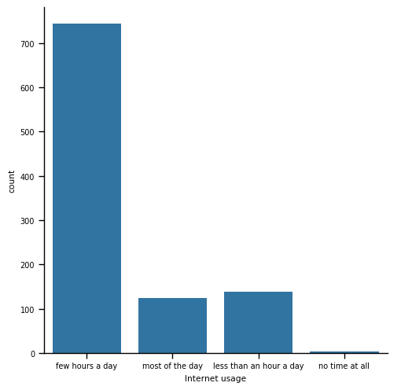

```python
# Create count plot of internet usage
sns.catplot(x="Internet usage", data=survey_data,
            kind="count")
```

```python
plt.close()  # added/edited
```

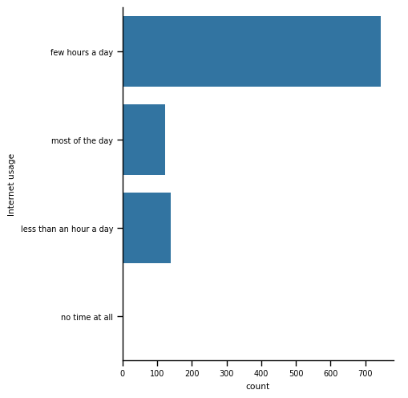

```python
# Change the orientation of the plot
sns.catplot(y="Internet usage", data=survey_data,
            kind="count")
```

```python
plt.close()  # added/edited
```

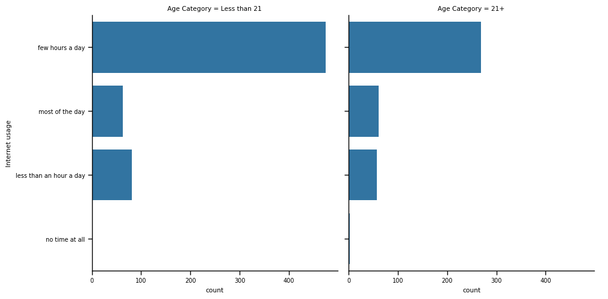

```python
# Separate into column subplots based on age category
sns.catplot(y="Internet usage", data=survey_data,
            kind="count", col="Age Category")
```

```python
plt.close()  # added/edited
```

## 3.2 Bar plots with percentages

Let’s continue exploring the responses to a survey sent out to young people. The variable `"Interested in Math"` is `True` if the person reported being interested or very interested in mathematics, and `False` otherwise. What percentage of young people report being interested in math, and does this vary based on gender? Let’s use a bar plot to find out.

As a reminder, we’ll create a bar plot using the `catplot()` function, providing the name of categorical variable to put on the x-axis (`x=____`), the name of the quantitative variable to summarize on the y-axis (`y=____`), the pandas DataFrame to use (`data=____`), and the type of categorical plot (`kind="bar"`).

Seaborn has been imported as `sns` and `matplotlib.pyplot` has been imported as `plt`.

**Instructions**

- Use the `survey_data` DataFrame and `sns.catplot()` to create a bar plot with `"Gender"` on the x-axis and `"Interested in Math"` on the y-axis.

**Answer**

```python
# added/edited
sns.reset_defaults()
survey_data = pd.read_csv("survey_data.csv")
```

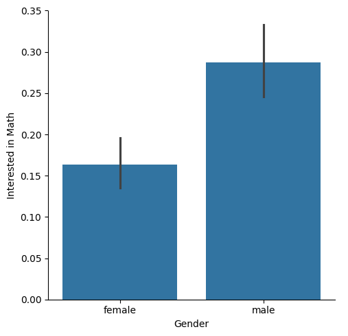

```python
# Create a bar plot of interest in math, separated by gender
sns.catplot(x="Gender", y="Interested in Math",
            data=survey_data, kind="bar")
```

```python
plt.close()  # added/edited
```

## 3.3 Customizing bar plots

In this exercise, we’ll explore data from students in secondary school. The `"study_time"` variable records each student’s reported weekly study time as one of the following categories: `"<2 hours"`, `"2 to 5 hours"`, `"5 to 10 hours"`, or `">10 hours"`. Do students who report higher amounts of studying tend to get better final grades? Let’s compare the average final grade among students in each category using a bar plot.

Seaborn has been imported as `sns` and `matplotlib.pyplot` has been imported as `plt`.

**Instructions**

- Use `sns.catplot()` to create a bar plot with `"study_time"` on the x-axis and final grade (`"G3"`) on the y-axis, using the `student_data` DataFrame.
- Using the `order` parameter and the `category_order` list that is provided, rearrange the bars so that they are in order from lowest study time to highest.
- Update the plot so that it no longer displays confidence intervals.

**Answer**

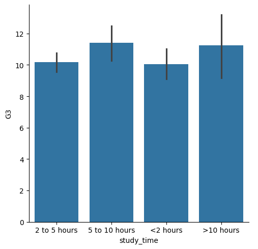

```python
# Create bar plot of average final grade in each study category
sns.catplot(x="study_time", y="G3",
            data=student_data,
            kind="bar")
```

```python
plt.close()  # added/edited
```

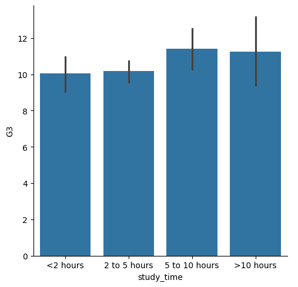

```python
# List of categories from lowest to highest
category_order = ["<2 hours",
                  "2 to 5 hours",
                  "5 to 10 hours",
                  ">10 hours"]

# Rearrange the categories
sns.catplot(x="study_time", y="G3",
            data=student_data,
            kind="bar",
            order=category_order)
```

```python
plt.close()  # added/edited
```

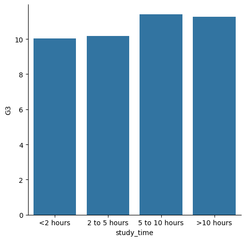

```python
# List of categories from lowest to highest
category_order = ["<2 hours",
                  "2 to 5 hours",
                  "5 to 10 hours",
                  ">10 hours"]

# Turn off the confidence intervals
sns.catplot(x="study_time", y="G3",
            data=student_data,
            kind="bar",
            order=category_order,
            ci=None)
```

```python
plt.close()  # added/edited
```

## 3.4 Create and interpret a box plot

Let’s continue using the `student_data` dataset. In an earlier exercise, we explored the relationship between studying and final grade by using a bar plot to compare the average final grade (`"G3"`) among students in different categories of `"study_time"`.

In this exercise, we’ll try using a box plot look at this relationship instead. As a reminder, to create a box plot you’ll need to use the `catplot()` function and specify the name of the categorical variable to put on the x-axis (`x=____`), the name of the quantitative variable to summarize on the y-axis (`y=____`), the pandas DataFrame to use (`data=____`), and the type of plot (`kind="box"`).

We have already imported `matplotlib.pyplot` as `plt` and `seaborn` as `sns`.

**Instructions**

- Use `sns.catplot()` and the `student_data` DataFrame to create a box plot with `"study_time"` on the x-axis and `"G3"` on the y-axis. Set the ordering of the categories to `study_time_order`.

**Answer**

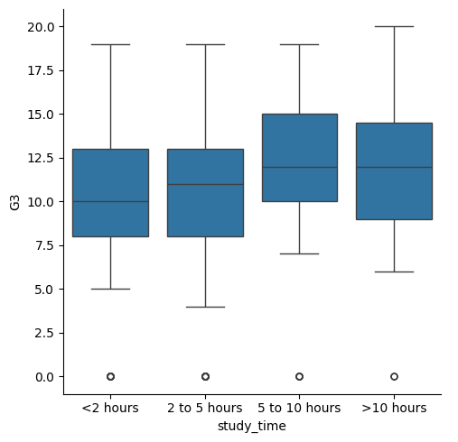

```python
# Specify the category ordering
study_time_order = ["<2 hours", "2 to 5 hours",
                    "5 to 10 hours", ">10 hours"]

# Create a box plot and set the order of the categories
sns.catplot(x="study_time", y="G3",
            data=student_data,
            kind="box",
            order=study_time_order)
```

```python
plt.close()  # added/edited
```

## 3.5 Omitting outliers

Now let’s use the `student_data` dataset to compare the distribution of final grades (`"G3"`) between students who have internet access at home and those who don’t. To do this, we’ll use the `"internet"` variable, which is a binary (yes/no) indicator of whether the student has internet access at home.

Since internet may be less accessible in rural areas, we’ll add subgroups based on where the student lives. For this, we can use the `"location"` variable, which is an indicator of whether a student lives in an urban (“Urban”) or rural (“Rural”) location.

Seaborn has already been imported as `sns` and `matplotlib.pyplot` has been imported as `plt`. As a reminder, you can omit outliers in box plots by setting the `sym` parameter equal to an empty string (`""`).

**Instructions**

- Use `sns.catplot()` to create a box plot with the `student_data` DataFrame, putting `"internet"` on the x-axis and `"G3"` on the y-axis.
- Add subgroups so each box plot is colored based on `"location"`.
- Do not display the outliers.

**Answer**

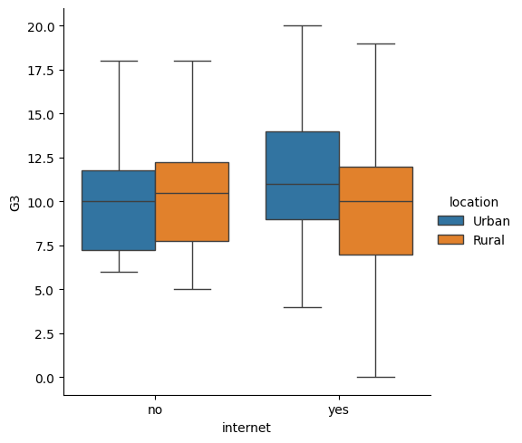

```python
# Create a box plot with subgroups and omit the outliers
sns.catplot(x="internet", y="G3",
            data=student_data,
            kind="box",
            hue="location",
            flierprops={"marker": ""})  # added/edited
```

```python
plt.close()  # added/edited
```